# Time Series

Jiawei Yu

04/12/2020

Let’s take a look at the data format:

```
## Rows: 818,148
## Columns: 8
## $ X             <int> 1, 2, 3, 4, 5, 6, 7, 8, 9, 10, 11, 12, 13, 14, 15, 16...
## $ created_at    <date> 2020-07-31, 2020-09-13, 2019-07-07, 2020-05-13, 2019...
## $ asking_price  <dbl> 1470000, 849999, 1049900, 1298000, 969900, 889900, 67...
## $ closed_price  <dbl> 1437000, 880000, 1014000, 1150000, 941000, 880000, 67...
## $ sqft_min      <int> 3500, 1100, 0, 0, 2000, 1100, 0, NA, NA, 1500, 1500, ...
## $ sqft_max      <int> 5000, 1500, NA, NA, 2500, 1500, NA, NA, NA, 2000, 200...
## $ property_type <chr> "Detached", "Detached", "Detached", "Detached", "Deta...
## $ end_date      <date> 2020-07-31, 2020-09-03, 2019-06-05, 2020-05-06, 2019...
```

`created_at` refers to when the data appeared in the database, and `end_date` refers to the date the deal is made.

How many deals are done each year?

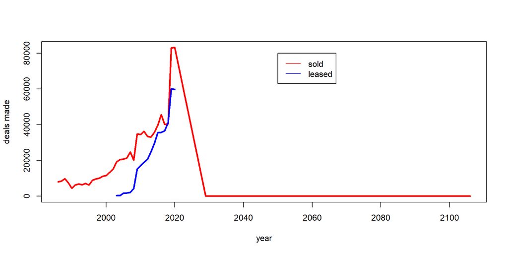

For the sold data, there are NAs in end_date, and some have dates way into the future. The leased data looks more normal. We should restrict the data range so that everything happens before 2020 (as it should!)

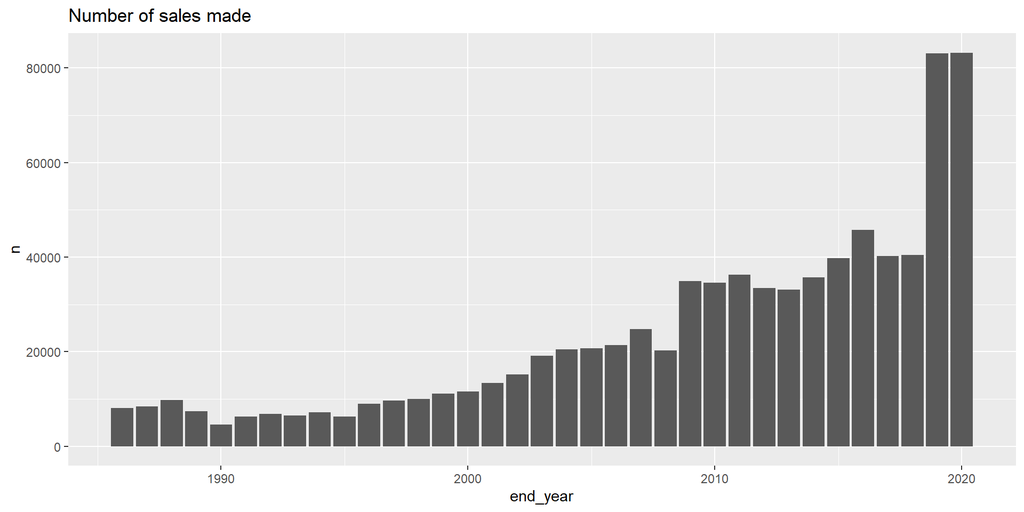

The first data dates back to 1986, but the company [Property.ca Realty Inc](https://www.linkedin.com/company/condos-ca/about/) was founded in 2008. Therefore, either these data are problematic, or they are from some other data sources. Moreover, the year 2019 and 2020 have much more data than the other years. Since our primary focus is the effects of seasonality and the effects of COVID-19, we select the data from year 2019 and 2020 only. The amount of data left is:

```
## # A tibble: 1 x 2
##   `Leased between 2019-20` `Sold between 2019-20`
##                      <int>                  <int>
## 1                   119893                 166269
```

# Times series: # of units sold or leased

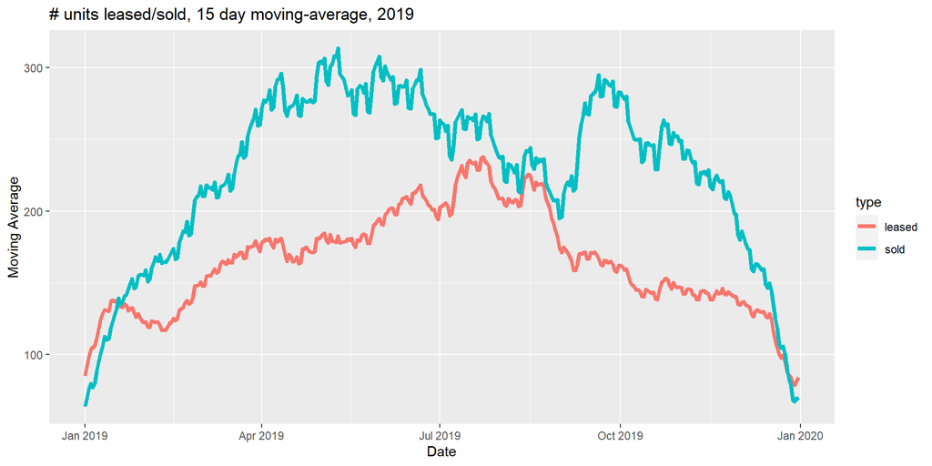

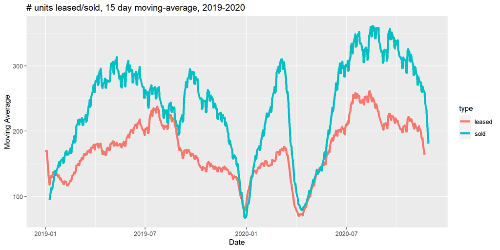

# Time series: price (bulk)

Since now we’re working with price data, we need to see if there’s any NA’s in both of the prices column:

|  | end_year | type | na_perct |
| --- | --- | --- | --- |
| 1 | 2010 | leased | 0.999 % |
| 2 | 2010 | sold | 0.081 % |
| 3 | 2011 | leased | 0.89 % |
| 4 | 2011 | sold | 0.05 % |
| 5 | 2012 | leased | 0.803 % |
| 6 | 2012 | sold | 0.087 % |
| 7 | 2013 | leased | 0.307 % |
| 8 | 2013 | sold | 0.063 % |
| 9 | 2014 | leased | 0.017 % |
| 10 | 2014 | sold | 0.05 % |

[output cut: 12 more lines]

We observe that, for most years, the percentage of data with missing prices (in either column) is small, and for each year after 2010 we have less than 1% of missing prices. Most notably, since 2014, the percentage of data with missing prices never exceeded 0.15%.  
Normally, with missing data we may wish to analyze them and see if we can identify any pattern that is inconsistent with normal data. However, with this little missing data, it is unlikely that they would have a noticeable impact on our analysis, even if they do follow a different pattern. Therefore I simply remove the missing data.

Moreover, we observe that, in the data, there are a number of rows (about 300) where the asking price and the closed price differ by a huge amount. Some of these are incidents where the sale price is listed, but the closed_price is a rent price (or vice versa), and some others are data errors. For example, these are the cases where asked_price is more than double the closed_price (or the other way around):

|  | X | created_at | asking_price | closed_price | sqft_min | sqft_max | property_type | end_date |
| --- | --- | --- | --- | --- | --- | --- | --- | --- |
| 1 | 511 | 2019-11-28 | 343000 | 1600 |  |  |  | 2008-03-13 |
| 2 | 1348 | 2020-08-17 | 1 | 2500000 | 0 |  | Vacant Land | 2020-08-17 |
| 3 | 1349 | 2020-08-17 | 1 | 2500000 | 0 |  | Detached | 2020-08-17 |
| 4 | 4425 | 2019-11-28 | 363323 | 1800 |  |  |  | 2009-02-03 |
| 5 | 10942 | 2019-11-28 | 224800 | 6780 |  |  |  | 2003-06-13 |
| 6 | 14805 | 2019-11-28 | 269900 | 1450 |  |  |  | 2005-05-09 |
| 7 | 15621 | 2020-04-08 | 0 | 650000 | 1200 | 1399 | Condo Townhouse | 2020-04-10 |
| 8 | 15810 | 2019-07-19 | 268000 | 1550 |  |  | Condo Apt | 2009-05-27 |
| 9 | 18114 | 2020-06-09 | 1550000 | 4300 | 0 |  | Detached | 2020-06-05 |
| 10 | 25687 | 2019-07-08 | 33 | 442000 | 800 | 899 | Condo Apt | 2018-02-28 |

[output cut: 316 more lines]

These are mostly outliers and are therefore ignored in our analysis.

What are the distribution of property types for sold data and leased data?

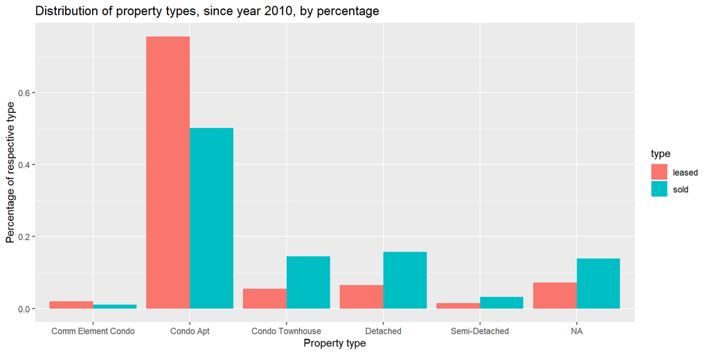

Sold properties are 50% condos, while leased properties are 75% condos. In our price analysis, we want to look at a particular type of property, to filter out the potential confounding effects from property types.

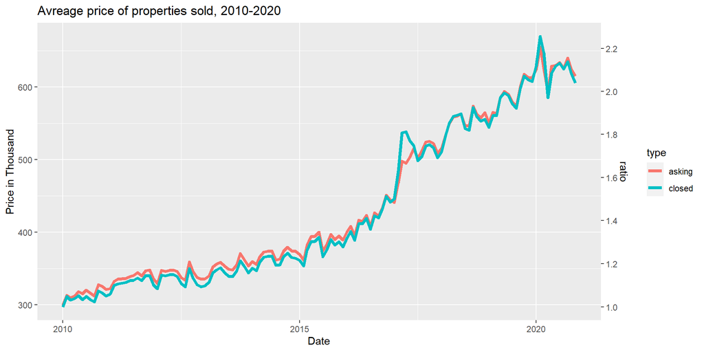

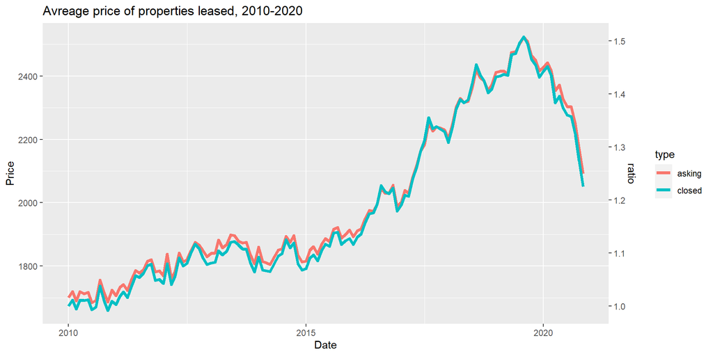

Sale price of properties have increased by 120% from 2010 to 2020.  
Rent prices, on the other hand, have grown by roughly 50% (before pandemic) over the same 10 years.  
While it’s understandable that sale price and rent price do not grow together (and the types of properties being sold v.s. being leased are different), we can conduct an additional analysis to see the price per sqft, instead of the bulk price.

# Time series: price (per sqft)

To calculate price per sqft, we need to first find the sqft data. There are two related variables, `sqft_min` and `sqft_max`. Since we’re only analyzing data from 2010-2020, we exclude data from other times.  
How many NA’s do we have in both columns?

```
## # A tibble: 8 x 6
## # Groups:   type, sqft_min_na [4]
##   type   sqft_min_na sqft_max_na  count avg_asking_price avg_closed_price
##   <chr>  <lgl>       <lgl>        <int>            <dbl>            <dbl>
## 1 leased FALSE       FALSE       257950            2117.            2102.
## 2 leased FALSE       TRUE             2            8475             7475
## 3 leased TRUE        FALSE        18533            1658.            1653.
## 4 leased TRUE        TRUE          9999            1626.            1605.
## 5 sold   FALSE       FALSE       230622          452396.          448961.
## 6 sold   FALSE       TRUE             1         7100000          7100000
## 7 sold   TRUE        FALSE         7300          341873.          341440.
## 8 sold   TRUE        TRUE         14585          276638.          271151.
```

Leased or sold data do not come with a separate `sqft` variable like active data, so we need to interpolate.  
For cases where both `sqft_min` and `sqft_max` is available, we simply take the average.  
To help us make interpolation decisions for data with missing values, let’s inspect the cases where at least one of the `sqft` columns is missing:

```
##     type sqft_min sqft_max     n
## 1 leased     5000       NA     2
## 2 leased       NA      499 18530
## 3 leased       NA      700     3
## 4 leased       NA       NA  9999
## 5   sold     5000       NA     1
## 6   sold       NA      499  7298
## 7   sold       NA      700     2
## 8   sold       NA       NA 14585
```

```
## # A tibble: 4 x 6
## # Groups:   type, sqft_min [4]
##   type   sqft_min sqft_max count mean_ask_price mean_closed_price
##   <chr>     <int>    <int> <int>          <dbl>             <dbl>
## 1 leased      500      599 48314          1784.             1778.
## 2 leased       NA      499 18530          1658.             1653.
## 3 sold        500      599 21756        388287.           389143.
## 4 sold         NA      499  7298        341880.           341450.
```

As one can see, those with `sqft_min = NA` and `sqft_max = 499` actually have similar average price as properties with sqft between 500 and 599 (the ratio is about 90%).  
If we assume that $P(sqft|sqft \in [500,599]) \sim Uniform(500,599)$, then we can observe that 90% of $550 sqft$ is 495, a number very close to 499. Therefore, in this case, we simply set `sqft` to 499.  
This actually justifies our decisions for `sqft` interpolation in the regression analysis.

In summary, our interpolation of `sqft` involves: * Taking the mean between `sqft_min` and `sqft_max` when both are non-NA * Setting `sqft` = 5000 when `sqft_max` is missing but `sqft_min` is not * Setting `sqft` = 499 when `sqft_max = 499` and `sqft_min` is missing * Ignoring entries where `sqft_max` = 700 and `sqft_min` is missing * Ignoring entries where `sqft_min` and `sqft_max` are both NA

After interpolating sqft, we can proceed to calculate `price/sqft`:

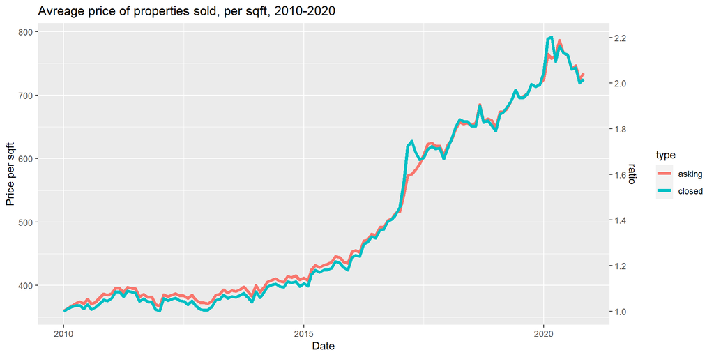

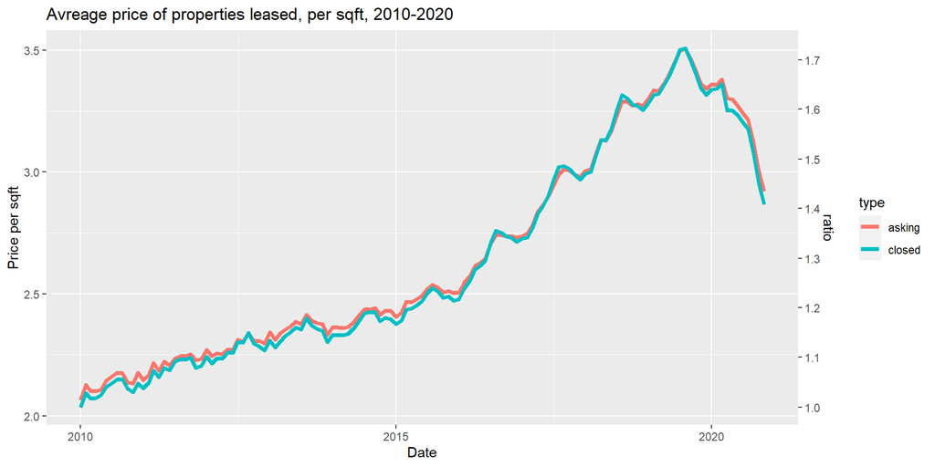

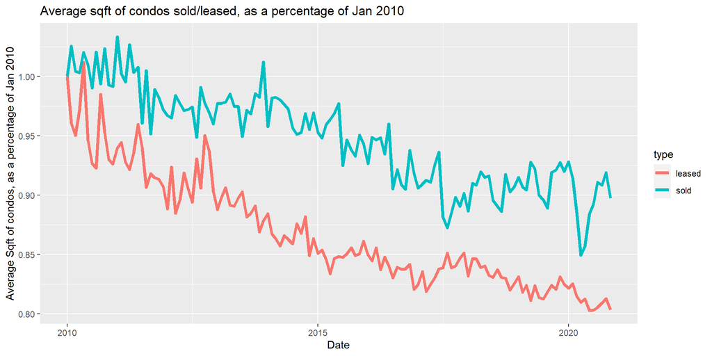

The average sqft of condos for sale has decreased by 10% over the last 10 years, but the average sqft of condos for rent has decreased by 20% over the past 10 years.